# Gradient Descent

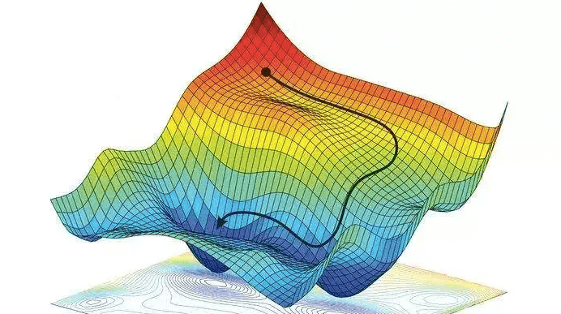

# Setup

```python
import numpy as np
import pandas as pd
import matplotlib.pyplot as plt

from sklearn.datasets import make_regression
from sklearn.datasets import make_classification

from sklearn.metrics import confusion_matrix
from sklearn.metrics import classification_report

from pprint import pprint
from IPython.display import Image
from IPython.core.display import HTML
```

# Linear Regression

## Data

```python
X, y = make_regression(n_samples=100, n_features=1, bias=3, noise=8)
X = np.squeeze(X)
```

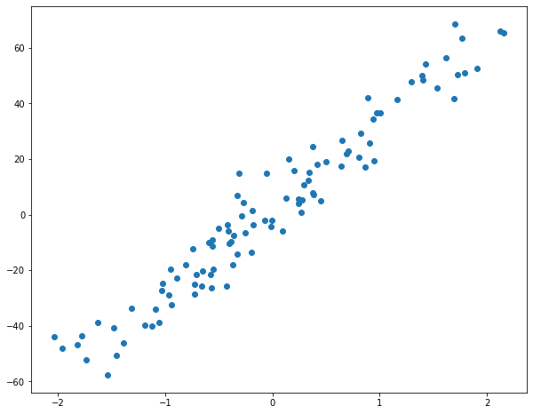

```python
plt.figure(figsize=(10,8))
plt.scatter(X, y)
```

## Formulation

```python
m = np.random.uniform(-3, 3)
b = np.random.uniform(-20, 20)
print(f'y = {m:.3f} X + {b:.3f}')
```

```
y = 2.803 X + 3.697
```

```python
def abline(slope, intercept, shape='--', color='red'):
    ax = plt.gca()
    _x = np.array(ax.get_xlim())
    _y = intercept + slope * _x
    plt.plot(_x, _y, shape, color='red')
    plt.title(f'y = {slope:.3f} X + {intercept:.3f}')
```

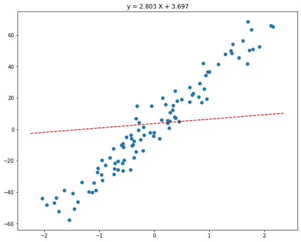

```python
plt.figure(figsize=(10,8))
plt.scatter(X, y)
abline(m, b)
```

## Weights

- Generate a random slope and intercept

```python
def initializeWeights():
    m = np.random.uniform(-3, 3)
    b = np.random.uniform(-20, 20)
    print(f'y = {m:.3f} X + {b:.3f}')
    return m, b
```

## Prediction

- Compute a prediction for each X value
- Use the formula y = mX + b

```python
def linearPredict(X, slope, intercept):
    pred = X * slope + intercept
    return pred
```

## Loss

- Compute the overall loss function
- Mean squared differences

```python
def linearLoss(predicted, actual):
    n = predicted.shape[0]
    mse = np.sum((predicted - actual) ** 2) / n
    return mse
```

## Derivatives

```python
def derivativeSlope(X, predicted, actual):
    deriv = -2 * np.sum(X * (actual - predicted))
    return deriv
```

```python
def derivativeIntercept(X, predicted, actual):
    deriv = -2 * np.sum(actual - predicted)
    return deriv
```

## Update

```python
def linearUpdate(slope, intercept, derivativeSlope, derivativeIntercept, lr=0.001):
    slope     = slope     - lr * derivativeSlope
    intercept = intercept - lr * derivativeIntercept
    return slope, intercept
```

## Initial Slope Intercept

```
y = -2.165 X + -13.544
```

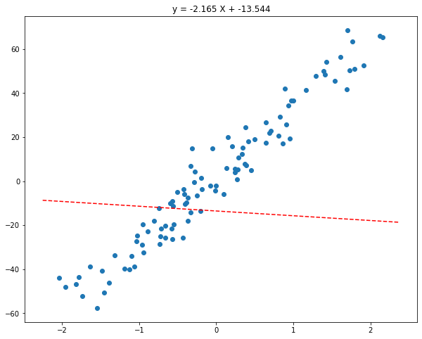

```python
slope, intercept = initializeWeights()
plt.figure(figsize=(10,8))
plt.scatter(X, y)
abline(slope, intercept)
```

```python
epochs = 100
losses = []

for e in range(epochs):
    pred = linearPredict(X, slope, intercept)
    loss = linearLoss(pred, y)
    losses.append(loss)
    dSlope     = derivativeSlope(X, pred, y)
    dIntercept = derivativeIntercept(X, pred, y)
    slope, intercept = linearUpdate(slope, intercept, dSlope, dIntercept)
```

## Ending Slope Intercept

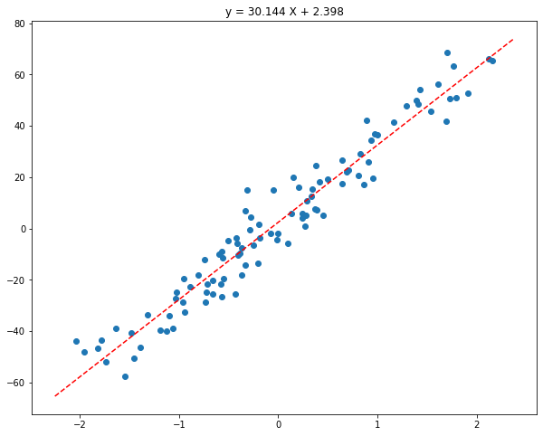

```python
plt.figure(figsize=(10,8))
plt.scatter(X, y)
abline(slope, intercept)
```

## Losses by Epoch

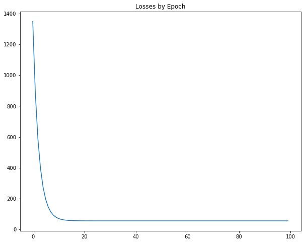

```python
plt.figure(figsize=(10,8))
plt.plot(losses)
plt.title('Losses by Epoch');
```

# Logistic Regression

- Logistic Regression is a statisical model
- It uses the logistic function to model the dependent variable
- It forms the basis of many neurons used to classify

## Data

```python
X_logistic, y_logistic = make_classification(n_classes=2, n_clusters_per_class=1, random_state=12,
                                             n_features=2, n_informative=1, n_redundant=0)
y_logistic.shape
```

```
(100,)
```

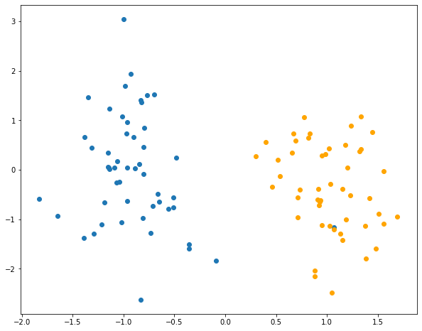

```python
plt.figure(figsize=(10,8))
for idx, color in enumerate(['#1f77b4', 'orange']):
    plt.scatter(X_logistic[y_logistic==idx][:,0], X_logistic[y_logistic==idx][:,1], color=color)
```

## Formulation

- Sigmoid is a bounded, differentiable function
- It approaches 1 as X gets large and 0 as X gets small
- At 0 the value is 0.5
- With respect to neural network activations, we can saturate
  - Saturation occurs when X is very large or small
  - At those points, the derivative is very small
  - Learning can be slow with a saturated neuron

```python
def sigmoid(x):
    return 1 / (1 + np.exp(-x))
```

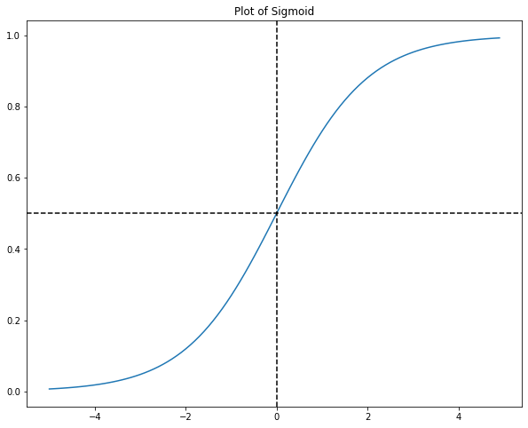

```python
plot_x = np.arange(-5,5,0.1)
plot_y = sigmoid(plot_x)
plt.figure(figsize=(10,8))
plt.plot(plot_x, plot_y)
ax = plt.gca()
ax.axvline(x=0.0, ls='--', color='black')
ax.axhline(y=0.5, ls='--', color='black')
plt.title('Plot of Sigmoid');
```

## Weights

- Randomly initialize weights
- We'll have two parameters in this example

```python
def initializeParameters(n_params=2):
    return np.random.uniform(-5, 5, n_params)
```

## Prediction

- We take the sigmoid of the dot / inner product of our data X and two parameters
- We round this to 0 or 1 to determine the class

```python
def predictLogistic(X, parameters):
    return sigmoid(np.dot(X, parameters))

def predictClasses(X, parameters):
    return np.round(sigmoid(np.dot(X, parameters)))
```

## Loss

```python
def logisticLoss(pred, y):
    eps = 1e-06
    cost = (-y).T @ np.log(pred + eps) - (1 - y).T @ np.log(1 - pred + eps)
    return cost
```

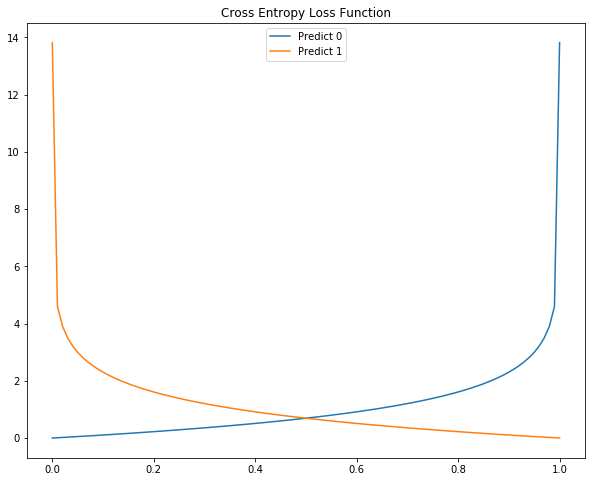

```python
plt.figure(figsize=(10,8))
plot_x = np.linspace(0,1,100)
loss0 = -np.log(1 - plot_x + 1.e-06)
loss1 = -np.log(plot_x + 1.e-06)
plt.plot(plot_x, loss0, label='Predict 0')
plt.plot(plot_x, loss1, label='Predict 1')
plt.title('Cross Entropy Loss Function')
plt.legend();
```

## Derivatives

- https://medium.com/mathematics-behind-optimization-of-cost-function/derivative-of-log-loss-function-for-logistic-regression-9b832f025c2d

```python
def derivativeLogistic(params, X, y):
    m = X.shape[0]
    dParams = (1 / m) * np.dot(X.T, (sigmoid(X @ params) - y))
    return dParams
```

## Update

```python
def updateParameters(params, dParams, lr=0.01):
    params = params - lr * dParams
    return params
```

## Learning

```python
epochs = 5000
losses = []
params = initializeParameters()
original_params = params.copy()

y_hat_original = predictClasses(X_logistic, params)

for e in range(epochs):
    preds = predictLogistic(X_logistic, params)
    loss  = logisticLoss(preds, y_logistic)
    losses.append(loss)
    dParams = derivativeLogistic(params, X_logistic, y_logistic)
    params  = updateParameters(params, dParams)

y_hat_complete = predictClasses(X_logistic, params)
```

## Beginning Errors

- Red is a point where we failed
- Green is a point we got corrent

```
              precision    recall  f1-score   support

         0.0       0.16      0.16      0.16        49
         1.0       0.16      0.16      0.16        51

    accuracy                           0.16       100
   macro avg       0.16      0.16      0.16       100
weighted avg       0.16      0.16      0.16       100
```

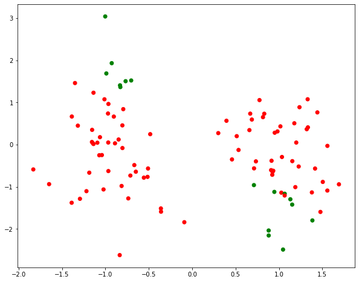

```python
plt.figure(figsize=(10,8))
correct = y_hat_original == y_logistic
color = np.where(correct == True, 'green', 'red')
plt.scatter(X_logistic[:,0], X_logistic[:,1], color=color)
print(classification_report(y_hat_original, y_logistic))
```

## Ending Errors

- After training we have only one data point incorrectly classified

```
              precision    recall  f1-score   support

         0.0       0.98      1.00      0.99        50
         1.0       1.00      0.98      0.99        50

    accuracy                           0.99       100
   macro avg       0.99      0.99      0.99       100
weighted avg       0.99      0.99      0.99       100
```

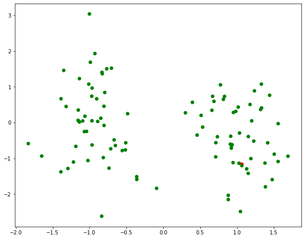

```python
plt.figure(figsize=(10,8))
correct = y_hat_complete == y_logistic
color = np.where(correct == True, 'green', 'red')
plt.scatter(X_logistic[:,0], X_logistic[:,1], color=color)
print(classification_report(y_hat_complete, y_logistic))
```

## Losses by Epoch

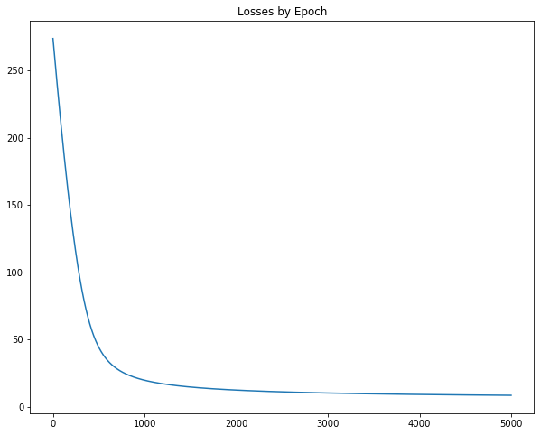

```python
plt.figure(figsize=(10,8))
plt.plot(losses)
plt.title('Losses by Epoch');
```

# Theory

## Capacity & XOR

- Neuron can solve a linearly separable problem
- A single neuron can't solve the XOR problem, because you can't map X to two Y locations
- To solve you have to transform the input into a different representation
- A multilayer perception with an OR, NAND and AND gate can provide a solution

```python
Image(url='https://i.stack.imgur.com/dY763.png')
```

[figure not shown]

## Universal Approximation Theorem

- A one layer hidden network or arbitrarily large size can approximate:
- Any differentiable function (continuous)
- Any boolean function (including XOR)